# LINKEDIN DATASET ASSESMENT

### DESCRIZIONE DATASET

Il dataset assegnatoci contiene i dati di profili LinkedIn anonimi di circa 15000 australiani. Include tutta la storia pregressa dei lavori ottenuti sino a quello corrente, insieme all’analisi particolareggiata delle loro foto.

Librerie

```r
library(dplyr)
library(ggplot2)
library(grid)
library(gridExtra)
library(tidyverse)
```

### ESPLORAZIONE DEL DATASET

A causa della mancanza di metadati dettagliati, sono state assunte le seguenti definizioni per le colonne del dataset.

**avg_n_pos_per_prev_tenure**: numero medio di posizioni occupate negli incarichi precedenti float

**avg_prev_tenure_len**: durata media degli incarichi precedenti float

**avg_pos_len** : la media della durata di ciascuna posizione ricoperta all’interno dell’azienda attuale float

**tenure_len**: la durata complessiva di tutte le posizioni ricoperte all’interno dell’azienda float

**n_prev_tenures** : numero di incarichi precedentemente ottenuti integer

**n_pos** : numero delle posizioni ricoperte all’interno dell’azienda attuale integer

**m_urn** : identificativo dell’utente string

**avg_prev_tenure_len** : media della durata complessiva degli incarichi precedenti ? ??incluso quello attuale??

**c_name** : nome dell’azienda string

**age** : età dell’utente integer

**beauty** : percentuale di bellezza. Se l’utente è uomo corrisponde al valore di beauty_male, mentre se è donna corrisponde al valore di beauty_female. float

**beauty_male** : percentuale di bellezza maschile dell’utente. float

**beauty_female** : percentuale di bellezza femminile dell’utente. float

**blur** : sfocatura dell’immagine integer

**blur_gaussian** : ? integer

**blur_motion** : ? integer

**emo_anger** : valore associato alla rabbia espressa nell’immagine integer

**emo_disgust** : valore associato al disgusto espresso nell’immagine integer

**emo_fear** : valore associato alla paura espressa nell’immagine integer

**emo_happines** : valore associato alla felicità espressa nell’immagine integer

**emo_neutrale** : valore associato alla neutralità dell’espressione integer

**emo_sadness** : valore associato alla tristezza espressa nell’immagine integer

**emo_surprise** : valore associato alla sorpresa espressa nell’immagine integer

**ethnicity** : etnia dell’utente string

**face_quality** : connotati facciali ? float

**gender** : sesso string

**glass** : variabile che esprime la presenza o meno di occhiali nella foto string

**head_pitch** : rotazione della testa rispetto all’asse passante per entrambe le orecchie float

**head_roll** : rotazione della testa rispetto all’asse perpendicolare al naso float

**head_yaw** : rotazione della testa rispetto all’asse verticale float

**img** : url dell’immagine dell’utente string

**mouth_close** : chiusura della bocca float

**mouth_mask** : copertura della bocca float

**mouth_open** : apertura della bocca float

**mouth_other** : ? float

**skin_acne** : presenza di acne sulla pelle float

**skin_dark_circle** : presenza di occhiaie float

**skin_health** : salute della pelle float

**skin_stain** : presenza di macchie sulla pelle float

**smile** : presenza del sorriso float

**african** : valore associato all’etnia africana visibile in foto float

**celtic_english** : valore associato all’etnia celtica visibile in foto float

**east_asian** : valore associato all’etnia est-asiatica visibile in foto float

**european** : valore associato all’etnia europea visibile in foto float

**greek** : valore associato all’etnia greca visibile in foto float

**hispanic** : valore associato all’etnia ispanica visibile in foto float

**jewish** : valore associato all’etnia ebrea visibile in foto float

**muslim** : valore associato all’etnia islamica visibile in foto float

**nationality** : nazionalità string

**nordic** : valore associato all’etnia nordica visibile in foto float

**south_asian** : valore associato all’etnia sud-asiatica visibile in foto float

**n_followers** : numero di seguaci integer

Sotto viene riportato il dataset nella sua interezza:

*Al fine di sviluppare un’analisi sui data relativi alle assunzioni mediante l’uso dei profili Linkedin, si selezionano i campi di interesse: età, sesso, numero di followers, etnia, bellezza, nazionalità, durata media degli incarichi precedenti, nome della compagnia, numero di incarichi precedenti, numero di posizioni ottenute all’interno della stessa azienda, durata dell’incarico attuale, durata media per posizione ottenuta attualmente nell’azienda.*

*Quindi se la persona ha assunto n posizioni diverse, allora avg_pos_len = tenute_len / n.*

```r
df <- dplyr::select(raw_data, avg_pos_len, avg_prev_tenure_len, c_name, n_pos, n_prev_tenures, tenure_len, age, beauty, beauty_female, beauty_male,
                   ethnicity, gender, nationality, n_followers, m_urn, smile) %>%
        filter(tenure_len > 0) %>%
        group_by(m_urn) %>%
        arrange(desc(n_prev_tenures)) %>%
        filter(age>16) %>%
        filter(age<65)%>%
        slice(1)
nrow(df)
```

[output not shown]

```r
df
```

| avg_pos_len | avg_prev_tenure_len | c_name | n_pos | n_prev_tenures | tenure_len | age | beauty | beauty_female | beauty_male | ethnicity | gender | nationality | n_followers | m_urn | smile |
| --- | --- | --- | --- | --- | --- | --- | --- | --- | --- | --- | --- | --- | --- | --- | --- |
| 2345.0000 | 3332.50000 | 360Insight | 1 | 2 | 2345 | 55 | 34.649 | 42.956 | 34.649 | White | Male | celtic_english | 664 | urn:li:member:10001616 | 98.378 |
| 814.2500 | 153.00000 | Orange Business Services | 4 | 1 | 3257 | 47 | 47.491 | 48.449 | 47.491 | White | Male | muslim | 1244 | urn:li:member:100022137 | 98.308 |
| 731.0000 | 77.00000 | Microsoft | 1 | 2 | 731 | 32 | 78.104 | 81.896 | 78.104 | White | Male | celtic_english | 461 | urn:li:member:100023129 | 8.622 |
| 426.0000 | 2729.66667 | Informatica | 1 | 3 | 426 | 50 | 35.416 | 35.416 | 33.303 | Asian | Female | east_asian | 805 | urn:li:member:10002837 | 98.893 |
| 1188.0000 | 1431.00000 | Microsoft | 1 | 5 | 1188 | 34 | 49.165 | 52.821 | 49.165 | Asian | Male | east_asian | 1274 | urn:li:member:100070614 | 11.534 |
| 805.5000 | 1810.50000 | Microsoft | 2 | 2 | 1611 | 62 | 43.382 | 43.382 | 41.989 | White | Female | celtic_english | 140 | urn:li:member:100095413 | 70.392 |
| 1005.0000 | 1901.50000 | KPMG US | 1 | 2 | 1005 | 45 | 47.502 | 46.329 | 47.502 | White | Male | celtic_english | 890 | urn:li:member:1001114 | 5.628 |
| 1127.0000 | 798.62500 | Sky | 1 | 8 | 1127 | 60 | 49.877 | 47.945 | 49.877 | Asian | Male | east_asian | 2147 | urn:li:member:10012899 | 20.274 |
| 458.0000 | 1871.33333 | Neudesic | 1 | 6 | 458 | 53 | 61.024 | 66.158 | 61.024 | White | Male | jewish | 701 | urn:li:member:1001303 | 51.921 |
| 184.0000 | 341.66667 | Gemeente Hengelo | 1 | 9 | 184 | 55 | 38.509 | 38.218 | 38.509 | White | Male | celtic_english | 557 | urn:li:member:10013966 | 77.743 |

[output cut: 990 more lines]

#### RICERCA DEI CAMPI DI INTERESSE

Si analizza il dataset risultante per individuare delle prime disuguaglianze riguardanti gli attributi.

###### ethnicity

```r
summary(df$ethnicity)
```

[output not shown]

```r
summary(df$gender)
```

```
Female   Male
  3650  11602
```

```r
summary(df$nationality)
```

[output not shown]

```r
round( summary(df$nationality) / nrow(df) * 100, 2)
```

[output not shown]

```r
xtabs(~ gender + ethnicity, data=df)
```

[output not shown]

```r
xtabs(~ nationality + ethnicity, data=df)
```

[output not shown]

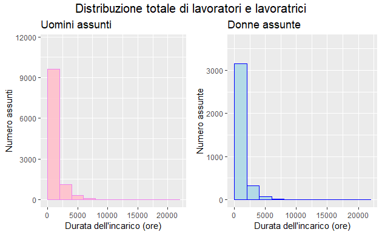

```r
h_male_total <- ggplot(data=filter(df, gender =="Male"), aes(tenure_len)) +
        geom_histogram(breaks=seq(0, 22000, by=2000),
                 col="violet",
                 fill="pink",
                 alpha = .9) +
        labs(title="Uomini assunti", x="Durata dell'incarico (ore)", y="Numero assunti") +
        ylim(c(0,11602))
h_female_total <- ggplot(data=filter(df, gender =="Female"), aes(tenure_len)) +
        geom_histogram(breaks=seq(0, 22000, by=2000),
                 col="blue",
                 fill="lightblue",
                 alpha = .9) +
        labs(title="Donne assunte", x="Durata dell'incarico (ore)", y="Numero assunte") +
        ylim(c(0,3650))
title <- textGrob("Distribuzione totale di lavoratori e lavoratrici", gp=gpar(fontsize=15, font=1))
grid.arrange(h_male_total, h_female_total,  ncol = 2, top=title)
```

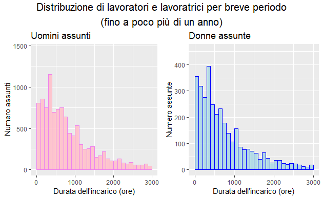

```r
h_male_low <- ggplot(data=filter(df, gender =="Male"), aes(tenure_len)) +
        geom_histogram(breaks=seq(0, 3000, by=100),
                 col="violet",
                 fill="pink",
                 alpha = .9) +
        labs(title="Uomini assunti", x="Durata dell'incarico (ore)", y="Numero assunti") +
        ylim(c(0,1450))
h_female_low <- ggplot(data=filter(df, gender =="Female"), aes(tenure_len)) +
        geom_histogram(breaks=seq(0, 3000, by=100),
                 col="blue",
                 fill="lightblue",
                 alpha = .9) +
        labs(title="Donne assunte", x="Durata dell'incarico (ore)", y="Numero assunte") +
        ylim(c(0, 456))
title <- textGrob("Distribuzione di lavoratori e lavoratrici per breve periodo\n(fino a poco più di un anno)", gp=gpar(fontsize=15, font=1))
grid.arrange(h_male_low, h_female_low,  ncol = 2, top=title)
```

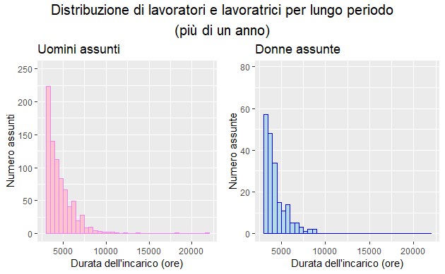

```r
h_male_high <- ggplot(data=filter(df, gender =="Male"), aes(tenure_len)) +
        geom_histogram(breaks=seq(3000, 22000, by=500),
                 col="violet",
                 fill="pink",
                 alpha = .9) +
        labs(title="Uomini assunti", x="Durata dell'incarico (ore)", y="Numero assunti") +
        ylim(c(0,250))
h_female_high <- ggplot(data=filter(df, gender =="Female"), aes(tenure_len)) +
        geom_histogram(breaks=seq(3000, 22000, by=500),
                 col="blue",
                 fill="lightblue",
                 alpha = .9) +
        labs(title="Donne assunte", x="Durata dell'incarico (ore)", y="Numero assunte") +
        ylim(c(0, 79))
title <- textGrob("Distribuzione di lavoratori e lavoratrici per lungo periodo\n(più di un anno)", gp=gpar(fontsize=15, font=1))
grid.arrange(h_male_high, h_female_high,  ncol = 2, top=title)
```

** Nei grafici abbiamo usato sempre limiti sulle y proporzionali al numero totale di persone appartenenti a una certa categoria nell’intero dataset.

Ripetiamo la stessa analisi condotta sui generi anche sulle diverse etnie.

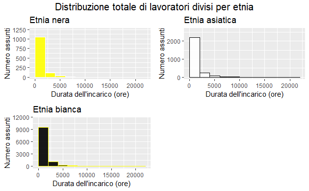

```r
h_black_total <- ggplot(data=filter(df, ethnicity=="Black"), aes(tenure_len)) +
        geom_histogram(breaks=seq(0, 22000, by=2000),
                 col="white",
                 fill="yellow",
                 alpha = .9) +
        labs(title="Etnia nera", x="Durata dell'incarico (ore)", y="Numero assunti") +
        ylim(c(0,1225))
h_asian_total <- ggplot(data=filter(df, ethnicity=="Asian"), aes(tenure_len)) +
        geom_histogram(breaks=seq(0, 22000, by=2000),
                 col="black",
                 fill="white",
                 alpha = .9) +
        labs(title="Etnia asiatica", x="Durata dell'incarico (ore)", y="Numero assunti") +
        ylim(c(0,2593))
h_white_total <- ggplot(data=filter(df, ethnicity =="White"), aes(tenure_len)) +
        geom_histogram(breaks=seq(0, 22000, by=2000),
                 col="yellow",
                 fill="black",
                 alpha = .9) +
        labs(title="Etnia bianca", x="Durata dell'incarico (ore)", y="Numero assunti") +
        ylim(c(0,11434))
title <- textGrob("Distribuzione totale di lavoratori divisi per etnia", gp=gpar(fontsize=15, font=1))
grid.arrange(h_black_total, h_asian_total, h_white_total,  ncol = 2, top=title)
```

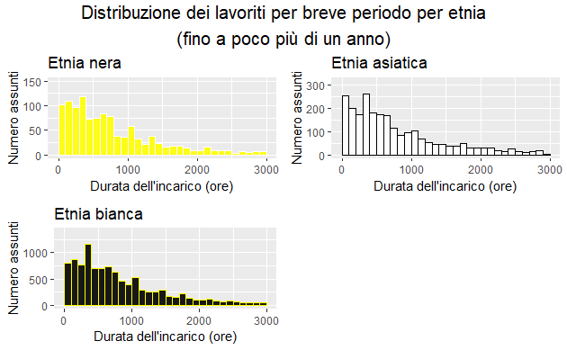

```r
h_white_low <- ggplot(data=filter(df, ethnicity =="White"), aes(tenure_len)) +
        geom_histogram(breaks=seq(0, 3000, by=100),
                 col="yellow",
                 fill="black",
                 alpha = .9) +
        labs(title="Etnia bianca", x="Durata dell'incarico (ore)", y="Numero assunti") +
        ylim(c(0,1401))
h_black_low <- ggplot(data=filter(df, ethnicity =="Black"), aes(tenure_len)) +
        geom_histogram(breaks=seq(0, 3000, by=100),
                 col="white",
                 fill="yellow",
                 alpha = .9) +
        labs(title="Etnia nera", x="Durata dell'incarico (ore)", y="Numero assunti") +
        ylim(c(0, 150))
h_asian_low <- ggplot(data=filter(df, ethnicity =="Asian"), aes(tenure_len)) +
        geom_histogram(breaks=seq(0, 3000, by=100),
                 col="black",
                 fill="white",
                 alpha = .9) +
        labs(title="Etnia asiatica", x="Durata dell'incarico (ore)", y="Numero assunti") +
        ylim(c(0, 318))
title <- textGrob("Distribuzione dei lavoriti per breve periodo per etnia\n(fino a poco più di un anno)", gp=gpar(fontsize=15, font=1))
grid.arrange(h_black_low, h_asian_low, h_white_low, ncol = 2, top=title)
```

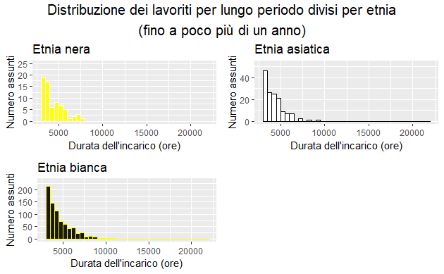

```r
h_white_high <- ggplot(data=filter(df, ethnicity =="White"), aes(tenure_len)) +
        geom_histogram(breaks=seq(3000, 22000, by=500),
                 col="yellow",
                 fill="black",
                 alpha = .9) +
        labs(title="Etnia bianca", x="Durata dell'incarico (ore)", y="Numero assunti") +
        ylim(c(0,234))
h_black_high <- ggplot(data=filter(df, ethnicity =="Black"), aes(tenure_len)) +
        geom_histogram(breaks=seq(3000, 22000, by=500),
                 col="white",
                 fill="yellow",
                 alpha = .9) +
        labs(title="Etnia nera", x="Durata dell'incarico (ore)", y="Numero assunti") +
        ylim(c(0, 25))
h_asian_high <- ggplot(data=filter(df, ethnicity =="Asian"), aes(tenure_len)) +
        geom_histogram(breaks=seq(3000, 22000, by=500),
                 col="black",
                 fill="white",
                 alpha = .9) +
        labs(title="Etnia asiatica", x="Durata dell'incarico (ore)", y="Numero assunti") +
        ylim(c(0, 53))
title <- textGrob("Distribuzione dei lavoriti per lungo periodo divisi per etnia\n(fino a poco più di un anno)", gp=gpar(fontsize=15, font=1))
grid.arrange(h_black_high, h_asian_high, h_white_high, ncol = 2, top=title)
```

Non sembra ci siano particolari discriminazioni a seconda dell’etnia e della durata dell’incarico ottenuto.

```r
not_working <- dplyr::select(raw_data, tenure_len, gender, ethnicity, beauty) %>%
        filter(tenure_len == 0)
nrow(not_working)
```

```
[1] 508
```

```r
summary(not_working$gender)
```

[output not shown]

```r
summary(not_working$ethnicity)
```

[output not shown]

```r
beauty_male <- ggplot(data=filter(df, gender =="Male"), aes(beauty_male)) +
        geom_histogram(breaks=seq(0, 100, by=5),
                 col="red",
                 fill="green",
                 alpha = .2) +
        labs(title="Uomini assunti", x="Valutazione della bellezza", y="Numero assunti") +
        ylim(c(0,10000))
beauty_female <- ggplot(data=filter(df, gender =="Female"), aes(beauty_female)) +
        geom_histogram(breaks=seq(0, 100, by=5),
                 col="red",
                 fill="green",
                 alpha = .2) +
        labs(title="Donne assunte", x="Valutazione della bellezza", y="Numero assunte") +
        ylim(c(0,10000))
grid.arrange(beauty_male, beauty_female,  ncol = 2)
```

[output not shown]

Dovremmo però vedere se i belli sono assunti per più tempo oppure no.

```r
beauty_male_not_w <- ggplot(data=filter(not_working, gender =="Male"), aes(beauty)) +
        geom_histogram(breaks=seq(0, 100, by=5),
                 col="red",
                 fill="green",
                 alpha = .2) +
        labs(title="Uomini non assunti", x="Valutazione della bellezza", y="Numero non assunti") +
        ylim(c(0,100))
beauty_female_not_w <- ggplot(data=filter(not_working, gender =="Female"), aes(beauty)) +
        geom_histogram(breaks=seq(0, 100, by=5),
                 col="red",
                 fill="green",
                 alpha = .2) +
        labs(title="Donne non assunte", x="Valutazione della bellezza", y="Numero non assunte") +
        ylim(c(0,100))
grid.arrange(beauty_male_not_w, beauty_female_not_w,  ncol = 2)
```

[output not shown]

```r
matrix_beauty_len <- dplyr::select(df, beauty, tenure_len)
plot(matrix_beauty_len)
```

[output not shown]

```r
females_working <- dplyr::select(df, beauty, tenure_len, gender, n_prev_tenures) %>%
        filter (gender == "Female")
nrow(females_working)
matrix_beauty_len_female <- dplyr::select(females_working, beauty, tenure_len)
plot(matrix_beauty_len_female)
```

[output not shown]

```r
males_working <- dplyr::select(df, beauty, tenure_len, gender) %>%
        filter (gender == "Male")
matrix_beauty_len_male <- dplyr::select(males_working, beauty, tenure_len)
plot(matrix_beauty_len_male)
```

[output not shown]

```r
matrix_age_len <- dplyr::select(df, age, tenure_len)
plot(matrix_age_len)
```

[output not shown]

```r
matrix_followers_len <- dplyr::select(df, n_followers, tenure_len)
plot(matrix_followers_len)
```

[output not shown]

```r
male_prev_pos <- ggplot(data=filter(df, gender =="Male"), aes(n_prev_tenures)) +
        geom_histogram(breaks=seq(1, 10, by=1),
                 col="red",
                 fill="green",
                 alpha = .2) +
        labs(title="Uomini assunti", x="Numero di incarichi precedenti", y="Uomini") +
        ylim(c(0,10000))
female_prev_pos <- ggplot(data=filter(df, gender =="Female"), aes(n_prev_tenures)) +
        geom_histogram(breaks=seq(1, 10, by=1),
                 col="red",
                 fill="green",
                 alpha = .2) +
        labs(title="Donne assunte", x="Numero di incarichi precedenti", y="Donne") +
        ylim(c(0,10000))
grid.arrange(male_prev_pos, female_prev_pos,  ncol = 2)
```

[output not shown]

```r
matrix_beauty_prev <- dplyr::select(females_working, beauty, n_prev_tenures)
plot(matrix_beauty_prev)
```

[output not shown]